# Project: Investigating US Accidents dataset from [kaggle](https://www.kaggle.com/datasets/sobhanmoosavi/us-accidents).

- Description
- Data Wrangling
- Data Cleaning
- Exploratory Data Analysis
- Questions regarding EDA
- Conclusions
- Summary

# Description

### This is a countrywide car accident dataset, which covers **49 states of the USA**. The accident data are collected from **February 2016 to Dec 2021**, using multiple APIs that provide streaming traffic incident (or event) data. These APIs broadcast traffic data captured by a variety of entities, such as the US and state departments of transportation, law enforcement agencies, traffic cameras, and traffic sensors within the road-networks. Currently, there are about **2.8 million** accident records in this dataset. Check [here](https://smoosavi.org/datasets/us_accidents) to learn more about this dataset.

# Data Wrangling

### Downloading the data from kaggle directly to aviod downloading the data to your local machine due to the large data size(1.5 GB).

```python
pip install opendatasets --upgrade --quiet
```

```python
import opendatasets as od

download_url = 'https://www.kaggle.com/datasets/sobhanmoosavi/us-accidents'

od.download(download_url)
```

```
Skipping, found downloaded files in "./us-accidents" (use force=True to force download)
```

```python
data_filename = './us-accidents/US_Accidents_Dec21_updated.csv'
```

### Importing the important packages

```python
import pandas as pd
import numpy as np
import matplotlib.pyplot as plt
import seaborn as sns
sns.set_style('whitegrid')
import warnings
warnings.filterwarnings('ignore')
```

```python
df = pd.read_csv(data_filename)
```

# Data Preparation and Cleaning

- Load the dataset file
- Discover the data information about the rows & columns
- Fix the missing/Nan/incorrect values in the data

```python
df.head()
```

|  | ID | Severity | Start_Time | End_Time | Start_Lat | Start_Lng | End_Lat | End_Lng | Distance(mi) | Description | ... | Roundabout | Station | Stop | Traffic_Calming | Traffic_Signal | Turning_Loop | Sunrise_Sunset | Civil_Twilight | Nautical_Twilight | Astronomical_Twilight |
| --- | --- | --- | --- | --- | --- | --- | --- | --- | --- | --- | --- | --- | --- | --- | --- | --- | --- | --- | --- | --- | --- |
| 0 | A-1 | 3 | 2016-02-08 00:37:08 | 2016-02-08 06:37:08 | 40.108910 | -83.092860 | 40.112060 | -83.031870 | 3.230 | Between Sawmill Rd/Exit 20 and OH-315/Olentang... | ... | False | False | False | False | False | False | Night | Night | Night | Night |
| 1 | A-2 | 2 | 2016-02-08 05:56:20 | 2016-02-08 11:56:20 | 39.865420 | -84.062800 | 39.865010 | -84.048730 | 0.747 | At OH-4/OH-235/Exit 41 - Accident. | ... | False | False | False | False | False | False | Night | Night | Night | Night |
| 2 | A-3 | 2 | 2016-02-08 06:15:39 | 2016-02-08 12:15:39 | 39.102660 | -84.524680 | 39.102090 | -84.523960 | 0.055 | At I-71/US-50/Exit 1 - Accident. | ... | False | False | False | False | False | False | Night | Night | Night | Day |
| 3 | A-4 | 2 | 2016-02-08 06:51:45 | 2016-02-08 12:51:45 | 41.062130 | -81.537840 | 41.062170 | -81.535470 | 0.123 | At Dart Ave/Exit 21 - Accident. | ... | False | False | False | False | False | False | Night | Night | Day | Day |
| 4 | A-5 | 3 | 2016-02-08 07:53:43 | 2016-02-08 13:53:43 | 39.172393 | -84.492792 | 39.170476 | -84.501798 | 0.500 | At Mitchell Ave/Exit 6 - Accident. | ... | False | False | False | False | False | False | Day | Day | Day | Day |

5 rows × 47 columns

```python
df.shape
```

```
(2845342, 47)
```

```python
df.columns
```

```
Index(['ID', 'Severity', 'Start_Time', 'End_Time', 'Start_Lat', 'Start_Lng',
       'End_Lat', 'End_Lng', 'Distance(mi)', 'Description', 'Number', 'Street',
       'Side', 'City', 'County', 'State', 'Zipcode', 'Country', 'Timezone',
       'Airport_Code', 'Weather_Timestamp', 'Temperature(F)', 'Wind_Chill(F)',
       'Humidity(%)', 'Pressure(in)', 'Visibility(mi)', 'Wind_Direction',
       'Wind_Speed(mph)', 'Precipitation(in)', 'Weather_Condition', 'Amenity',
       'Bump', 'Crossing', 'Give_Way', 'Junction', 'No_Exit', 'Railway',
       'Roundabout', 'Station', 'Stop', 'Traffic_Calming', 'Traffic_Signal',
       'Turning_Loop', 'Sunrise_Sunset', 'Civil_Twilight', 'Nautical_Twilight',
       'Astronomical_Twilight'],
      dtype='object')
```

```python
df.info()
```

```
<class 'pandas.core.frame.DataFrame'>
RangeIndex: 2845342 entries, 0 to 2845341
Data columns (total 47 columns):
 #   Column                 Dtype
---  ------                 -----
 0   ID                     object
 1   Severity               int64
 2   Start_Time             object
 3   End_Time               object
 4   Start_Lat              float64
 5   Start_Lng              float64
 6   End_Lat                float64
 7   End_Lng                float64
 8   Distance(mi)           float64
 9   Description            object
```

[output cut: 39 more lines]

```python
df.describe()
```

|  | Severity | Start_Lat | Start_Lng | End_Lat | End_Lng | Distance(mi) | Number | Temperature(F) | Wind_Chill(F) | Humidity(%) | Pressure(in) | Visibility(mi) | Wind_Speed(mph) | Precipitation(in) |
| --- | --- | --- | --- | --- | --- | --- | --- | --- | --- | --- | --- | --- | --- | --- |
| count | 2.845342e+06 | 2.845342e+06 | 2.845342e+06 | 2.845342e+06 | 2.845342e+06 | 2.845342e+06 | 1.101431e+06 | 2.776068e+06 | 2.375699e+06 | 2.772250e+06 | 2.786142e+06 | 2.774796e+06 | 2.687398e+06 | 2.295884e+06 |
| mean | 2.137572e+00 | 3.624520e+01 | -9.711463e+01 | 3.624532e+01 | -9.711439e+01 | 7.026779e-01 | 8.089408e+03 | 6.179356e+01 | 5.965823e+01 | 6.436545e+01 | 2.947234e+01 | 9.099391e+00 | 7.395044e+00 | 7.016940e-03 |
| std | 4.787216e-01 | 5.363797e+00 | 1.831782e+01 | 5.363873e+00 | 1.831763e+01 | 1.560361e+00 | 1.836009e+04 | 1.862263e+01 | 2.116097e+01 | 2.287457e+01 | 1.045286e+00 | 2.717546e+00 | 5.527454e+00 | 9.348831e-02 |
| min | 1.000000e+00 | 2.456603e+01 | -1.245481e+02 | 2.456601e+01 | -1.245457e+02 | 0.000000e+00 | 0.000000e+00 | -8.900000e+01 | -8.900000e+01 | 1.000000e+00 | 0.000000e+00 | 0.000000e+00 | 0.000000e+00 | 0.000000e+00 |
| 25% | 2.000000e+00 | 3.344517e+01 | -1.180331e+02 | 3.344628e+01 | -1.180333e+02 | 5.200000e-02 | 1.270000e+03 | 5.000000e+01 | 4.600000e+01 | 4.800000e+01 | 2.931000e+01 | 1.000000e+01 | 3.500000e+00 | 0.000000e+00 |
| 50% | 2.000000e+00 | 3.609861e+01 | -9.241808e+01 | 3.609799e+01 | -9.241772e+01 | 2.440000e-01 | 4.007000e+03 | 6.400000e+01 | 6.300000e+01 | 6.700000e+01 | 2.982000e+01 | 1.000000e+01 | 7.000000e+00 | 0.000000e+00 |
| 75% | 2.000000e+00 | 4.016024e+01 | -8.037243e+01 | 4.016105e+01 | -8.037338e+01 | 7.640000e-01 | 9.567000e+03 | 7.600000e+01 | 7.600000e+01 | 8.300000e+01 | 3.001000e+01 | 1.000000e+01 | 1.000000e+01 | 0.000000e+00 |
| max | 4.000000e+00 | 4.900058e+01 | -6.711317e+01 | 4.907500e+01 | -6.710924e+01 | 1.551860e+02 | 9.999997e+06 | 1.960000e+02 | 1.960000e+02 | 1.000000e+02 | 5.890000e+01 | 1.400000e+02 | 1.087000e+03 | 2.400000e+01 |

### *Figure out the length of numerical and categorical data*

```python
numerical_df = df.select_dtypes(include=['int64','float64'])
print(numerical_df.head())
print("The length of numerical columns is: ",len(numerical_df.columns))
```

```
   Severity  Start_Lat  Start_Lng    End_Lat    End_Lng  Distance(mi)  Number  \
0         3  40.108910 -83.092860  40.112060 -83.031870         3.230     NaN
1         2  39.865420 -84.062800  39.865010 -84.048730         0.747     NaN
2         2  39.102660 -84.524680  39.102090 -84.523960         0.055     NaN
3         2  41.062130 -81.537840  41.062170 -81.535470         0.123     NaN
4         3  39.172393 -84.492792  39.170476 -84.501798         0.500     NaN

   Temperature(F)  Wind_Chill(F)  Humidity(%)  Pressure(in)  Visibility(mi)  \
0            42.1           36.1         58.0         29.76            10.0
1            36.9            NaN         91.0         29.68            10.0
2            36.0            NaN         97.0         29.70            10.0
3            39.0            NaN         55.0         29.65            10.0
4            37.0           29.8         93.0         29.69            10.0

   Wind_Speed(mph)  Precipitation(in)
0             10.4               0.00
1              NaN               0.02
2              NaN               0.02
3              NaN                NaN
4             10.4               0.01
The length of numerical columns is:  14
```

```python
categorical_df = df.select_dtypes(include='object')
print(categorical_df.head())
print("The length of categorical columns is: ", len(categorical_df.columns))
```

```
    ID           Start_Time             End_Time  \
0  A-1  2016-02-08 00:37:08  2016-02-08 06:37:08
1  A-2  2016-02-08 05:56:20  2016-02-08 11:56:20
2  A-3  2016-02-08 06:15:39  2016-02-08 12:15:39
3  A-4  2016-02-08 06:51:45  2016-02-08 12:51:45
4  A-5  2016-02-08 07:53:43  2016-02-08 13:53:43

                                         Description       Street Side  \
0  Between Sawmill Rd/Exit 20 and OH-315/Olentang...  Outerbelt E    R
1                 At OH-4/OH-235/Exit 41 - Accident.       I-70 E    R
2                   At I-71/US-50/Exit 1 - Accident.       I-75 S    R
3                    At Dart Ave/Exit 21 - Accident.       I-77 N    R
4                 At Mitchell Ave/Exit 6 - Accident.       I-75 S    R

         City      County State Zipcode Country    Timezone Airport_Code  \
```

[output cut: 20 more lines]

*We have 14 numerical columns to deal with and 20 categorical columns*

**Checking for missing values**

```python
df.isnull().sum()
```

```
ID                             0
Severity                       0
Start_Time                     0
End_Time                       0
Start_Lat                      0
Start_Lng                      0
End_Lat                        0
End_Lng                        0
Distance(mi)                   0
Description                    0
Number                   1743911
Street                         2
Side                           0
City                         137
County                         0
State                          0
Zipcode                     1319
Country                        0
Timezone                    3659
Airport_Code                9549
Weather_Timestamp          50736
Temperature(F)             69274
Wind_Chill(F)             469643
Humidity(%)                73092
Pressure(in)               59200
Visibility(mi)             70546
Wind_Direction             73775
Wind_Speed(mph)           157944
Precipitation(in)         549458
Weather_Condition          70636
Amenity                        0
Bump                           0
Crossing                       0
Give_Way                       0
Junction                       0
No_Exit                        0
Railway                        0
Roundabout                     0
Station                        0
Stop                           0
Traffic_Calming                0
Traffic_Signal                 0
Turning_Loop                   0
Sunrise_Sunset              2867
Civil_Twilight              2867
Nautical_Twilight           2867
Astronomical_Twilight       2867
dtype: int64
```

# Exploratory Data Analysis (EDA) on the dataset.

*Missing values percentage of each column*

```python
missing_data_percentage = df.isnull().sum().sort_values(ascending=False)/len(df)*100
missing_data_percentage
```

```
Number                   61.290031
Precipitation(in)        19.310789
Wind_Chill(F)            16.505678
Wind_Speed(mph)           5.550967
Wind_Direction            2.592834
Humidity(%)               2.568830
Weather_Condition         2.482514
Visibility(mi)            2.479350
Temperature(F)            2.434646
Pressure(in)              2.080593
Weather_Timestamp         1.783125
Airport_Code              0.335601
Timezone                  0.128596
Nautical_Twilight         0.100761
Civil_Twilight            0.100761
Sunrise_Sunset            0.100761
Astronomical_Twilight     0.100761
Zipcode                   0.046356
City                      0.004815
Street                    0.000070
Country                   0.000000
Junction                  0.000000
Start_Time                0.000000
End_Time                  0.000000
Start_Lat                 0.000000
Turning_Loop              0.000000
Traffic_Signal            0.000000
Traffic_Calming           0.000000
Stop                      0.000000
Station                   0.000000
Roundabout                0.000000
Railway                   0.000000
No_Exit                   0.000000
Crossing                  0.000000
Give_Way                  0.000000
Bump                      0.000000
Amenity                   0.000000
Start_Lng                 0.000000
End_Lat                   0.000000
End_Lng                   0.000000
Distance(mi)              0.000000
Description               0.000000
Severity                  0.000000
Side                      0.000000
County                    0.000000
State                     0.000000
ID                        0.000000
dtype: float64
```

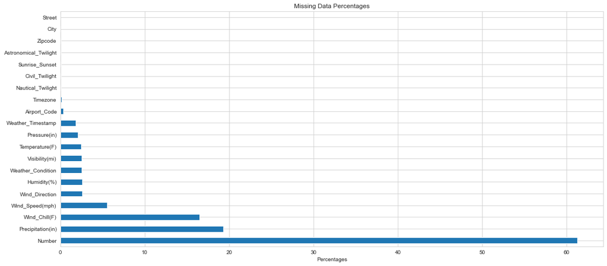

```python
missing_data_percentage[missing_data_percentage != 0].plot(kind='barh',figsize=(18,8), title='Missing Data Percentages', xlabel='Percentages');
```

**We need to avoid dealing with the columns with high percentage of missing data**

*Plotting the states counts*

```python
states = df.State.unique()
```

```python
states_counts = []
for i in states:
    states_counts.append(df[df['State']==i].count()['ID'])
```

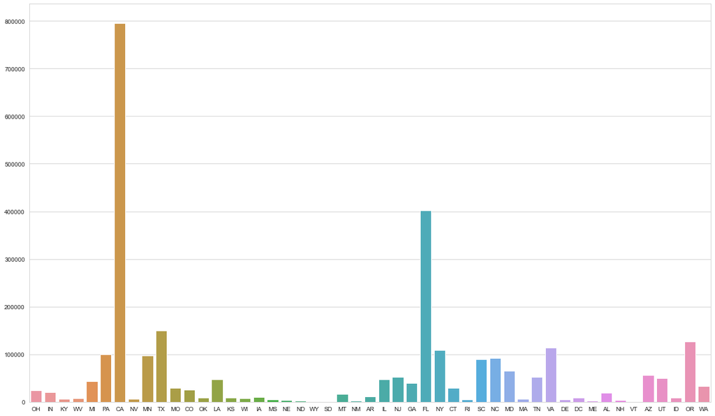

```python
fig,ax = plt.subplots(figsize=(20,12))
sns.barplot(states,states_counts);
```

#### **California 'CA' has the highest number of car accidents**

# Questions regarding EDA on the dataset.

*Q1: Who are the top 10 cities in the US by number of accidents?*

```python
cities_by_accidents = df['City'].value_counts()
cities_by_accidents[:10]
```

```
Miami          106966
Los Angeles     68956
Orlando         54691
Dallas          41979
Houston         39448
Charlotte       33152
Sacramento      32559
San Diego       26627
Raleigh         22840
Minneapolis     22768
Name: City, dtype: int64
```

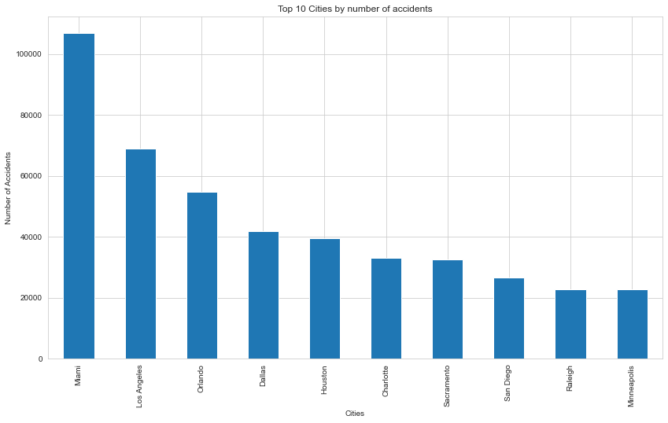

```python
fig, ax = plt.subplots(figsize=(14,8))
cities_by_accidents[:10].plot(kind='bar')
ax.set(title='Top 10 Cities by number of accidents',
      xlabel = 'Cities', ylabel='Number of Accidents')
plt.show();
```

#### Miami City has the highest number of accidents in the US

*Q2: Who are the top 10 states in the US by number of accidents?*

```python
state_by_accidents = df.State.value_counts()
state_by_accidents[:10]
```

```
CA    795868
FL    401388
TX    149037
OR    126341
VA    113535
NY    108049
PA     99975
MN     97185
NC     91362
SC     89216
Name: State, dtype: int64
```

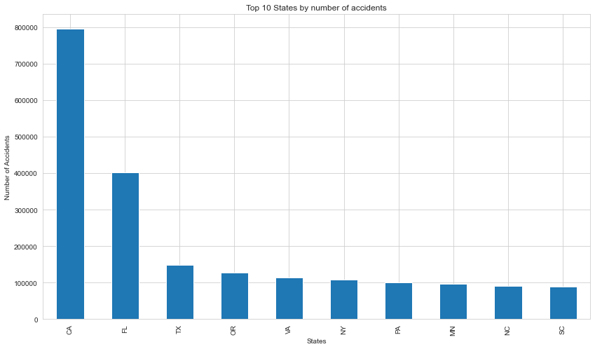

```python
fig, ax = plt.subplots(figsize=(14,8))
state_by_accidents[:10].plot(kind='bar')
ax.set(title='Top 10 States by number of accidents',
      xlabel = 'States', ylabel='Number of Accidents')
plt.show();
```

#### 'CA' has the highest number of accidents in the US.

*Q3: What is the percentage of severity of the overall accidents in the US?*

```python
severity_of_accidents = df.groupby('Severity').count()['ID']
severity_of_accidents
```

```
Severity
1      26053
2    2532991
3     155105
4     131193
Name: ID, dtype: int64
```

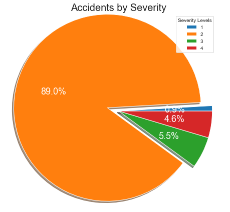

```python
fig, ax = plt.subplots(figsize=(12,6))
label = [1,2,3,4]
explode=(0,0.15,0,0)
ax.pie(severity_of_accidents, radius=1.2,explode=explode, labels=label, autopct='%1.1f%%',
        shadow=True,textprops={'fontsize':18, 'color':'white'})
ax.set_title('Accidents by Severity',fontdict={'fontsize': 20})
plt.legend(title='Severity Levels')
plt.tight_layout()
plt.show();
```

### The majority (89%) of the accidents were level 2 of severity, which seems normal.

*Q4: Which city has the highest severity level of accidents?*

```python
severity_of_cities = df.loc[df["Severity"] == 4].groupby('City').size().sort_values(ascending=False)
severity_of_cities
```

```
City
Miami         1580
Atlanta       1467
Orlando        927
Dallas         858
Washington     835
              ...
Headrick         1
Roodhouse        1
Conklin          1
Hazelhurst       1
Karns City       1
Length: 8660, dtype: int64
```

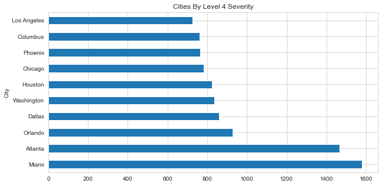

```python
severity_of_cities[:10].plot(kind='barh',figsize=(10,5),title='Cities By Level 4 Severity');
```

#### Miami City has the highest number of level 4 severity accidents

*Q5: Which state has the highest severity level of accidents?*

```python
severity_of_states = df.loc[df["Severity"] == 4].groupby('State').size().sort_values(ascending=False)
severity_of_states
```

```
State
FL    9581
CA    9135
PA    8882
VA    8571
NY    8100
MD    7755
GA    7372
MI    5513
OH    5222
NC    4656
TX    4467
NJ    4392
CO    4206
OR    4024
AZ    3902
IN    3469
IL    3209
WA    3129
CT    2896
WI    2677
TN    2096
MO    1769
SC    1702
IA    1478
UT    1352
AR    1258
LA    1184
DE    1035
AL     913
KY     814
DC     697
MN     627
WV     562
NV     517
KS     500
ID     448
NE     429
MA     414
MS     407
NM     402
OK     398
WY     260
MT     248
NH     193
RI     111
ME      96
VT      68
SD      44
ND      13
dtype: int64
```

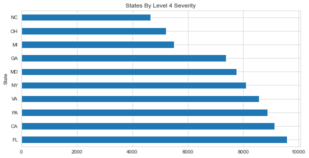

```python
severity_of_states[:10].plot(kind='barh',figsize=(10,5),title='States By Level 4 Severity');
```

#### 'FL' Florida has the highest number of level 4 severity accidents.

*Q5: What is the most repeatable time of the day/hour of the day the accidents occurs?*

```python
df.Start_Time.dtype, df.End_Time.dtype
```

```
(dtype('O'), dtype('O'))
```

**We need to convert the data type of the date to timestamp to deal with time correctly**

```python
df.Start_Time = pd.to_datetime(df.Start_Time)
df.End_Time = pd.to_datetime(df.End_Time)
```

```python
df.Start_Time.dtype, df.End_Time.dtype
```

```
(dtype('<M8[ns]'), dtype('<M8[ns]'))
```

**Now it's a timestamp format.**

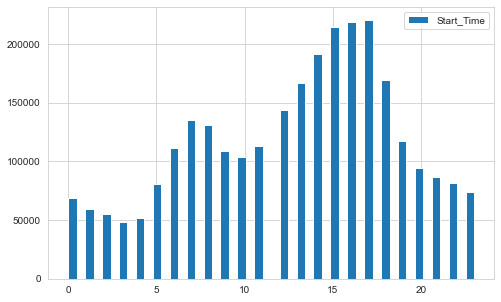

```python
# bins = 48 as 24*2 for clarity of the hours
df.Start_Time.dt.hour.hist(bins=48,figsize=(8,5),legend=True);
```

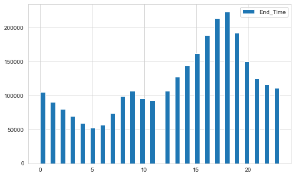

```python
df.End_Time.dt.hour.hist(bins=48,figsize=(8,5),legend=True);
```

#### As we can see from the histogram, the most repeatable hours are from (6 to 10 AM) as people going to work and also from (2 to 6 PM) as people going home from work

*Q6: What is the most repeatable day of the week the accidents occurs?*

```python
df.Start_Time.dt.dayofweek[0]
```

```
0
```

```python
repeatable_acc_day = df.Start_Time.dt.dayofweek
```

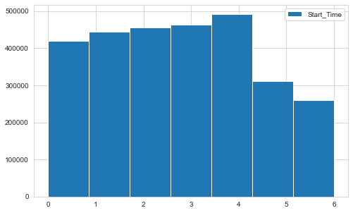

```python
repeatable_acc_day.hist(bins=7, figsize=(8,5),legend=True);
```

#### As day 0 is Monday the begininng of the week, it's a normal distribution over the weekdays with lower number of accidents in the weekends (day 6 and 6)

*Q7: What is the months that have high number of accidents?*

```python
month_by_accidents = df.Start_Time.dt.month
```

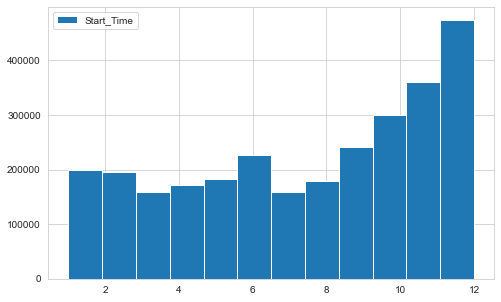

```python
month_by_accidents.hist(bins=12,figsize=(8,5),legend=True);
```

#### December (month 12) has the highest number of accidents occurs.

*Q8: Is the temperature and humidity is responsable for high number of accidents?*

```python
#As Miami city and FL state has the highest number of accidents
df_highest_city = df[df.City == 'Miami']
df_highest_state = df[df.State == 'FL']
```

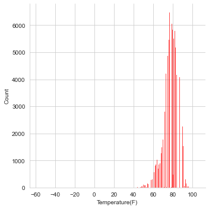

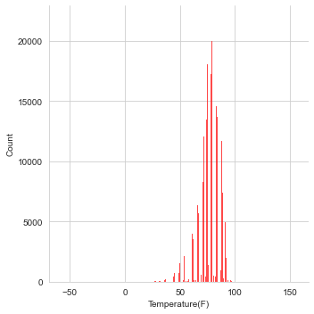

```python
sns.displot(df_highest_city['Temperature(F)'],kind='hist',color='red',legend=True);
sns.displot(df_highest_state['Temperature(F)'],kind='hist',color='red',legend=True);
```

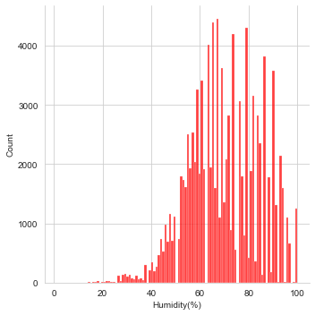

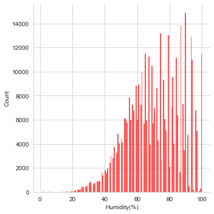

```python
sns.displot(df_highest_city['Humidity(%)'],kind='hist',color='red',legend=True);
sns.displot(df_highest_state['Humidity(%)'],kind='hist',color='red',legend=True);
```

##### Seems like the high number of accidnets were correlatted with the raises of the *Temperature Degrees* and *Humidity Percentages*

*Q9: Which side of the road that accidents occurs the most?*

```python
road_side = df.groupby(['Side']).count()['ID']
road_side
```

```
Side
L     492032
N          1
R    2353309
Name: ID, dtype: int64
```

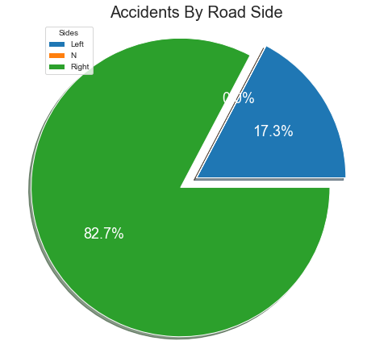

```python
# N side has nearly 0% occurnece but we can't exclude it because the length of the labels

fig, ax = plt.subplots(figsize=(12,6))
label = ['Left','N','Right']
explode=(0,0,0.15)
ax.pie(road_side, radius=1.2,explode=explode, labels=label, autopct='%1.1f%%',
        shadow=True,textprops={'fontsize':18, 'color':'white'})
ax.set_title('Accidents By Road Side',fontdict={'fontsize': 20})
plt.legend(title='Sides')
plt.tight_layout()
plt.show();
```

#### More than 80% of the accidents occurs on the right side of the street.

*Q10: What is the trend of accidents over the years?*

```python
# The dataset contains years from 2016 to 2021
df_2016 = df[df.Start_Time.dt.year == 2016].value_counts().sum()
df_2017 = df[df.Start_Time.dt.year == 2017].value_counts().sum()
df_2018 = df[df.Start_Time.dt.year == 2018].value_counts().sum()
df_2019 = df[df.Start_Time.dt.year == 2019].value_counts().sum()
df_2020 = df[df.Start_Time.dt.year == 2020].value_counts().sum()
df_2021 = df[df.Start_Time.dt.year == 2021].value_counts().sum()
```

```python
trend_of_accidents = [df_2016,df_2017,df_2018,df_2019,df_2020,df_2021]
years = [2016,2017,2018,2019,2020,2021]
```

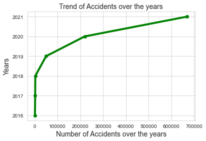

```python
plt.plot(trend_of_accidents,years,'o-g', linewidth=4)
plt.xlabel('Number of Accidents over the years',fontdict={'fontsize':14})
plt.ylabel('Years',fontdict={'fontsize':14})
plt.title('Trend of Accidents over the years',fontdict={'fontsize':14})
plt.show();
```

#### There's positive trend of accidents over the years which means that the US accidents count increases every year.

# Map of the US shows each accident coordinations with regard to its severity.

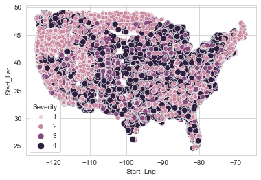

```python
sns.scatterplot(x=df.Start_Lng,y=df.Start_Lat,data=df,size=df.Severity, hue=df.Severity);
```

# Map shows the density of the accidents all over the US

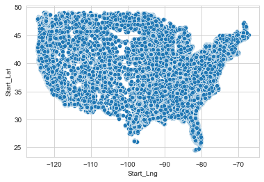

```python
sns.scatterplot(x=df.Start_Lng,y=df.Start_Lat,data=df);
```

# Conclusions

- We answered the following questions in the Questions regarding EDA part.
  - *Q1: Who are the top 10 cities in the US by number of accidents?*</a>
  - *Q2: Who are the top 10 states in the US by number of accidents?*
  - *Q3: What is the percentage of severity of the overall accidents in the US?*
  - *Q4: Which city has the highest severity level of accidents?*
  - *Q5: What is the most repeatable time of the day/hour of the day the accidents occurs?*
  - *Q6: What is the most repeatable day of the week the accidents occurs?*
  - *Q7: What is the months that have high number of accidents?*
  - *Q8: Is the temperature and humidity is responsable for high number of accidents?*
  - *Q9: Which side of the road that accidents occurs the most?*
  - *Q10: What is the trend of accidents over the years?*

# Summary

### Limitations:

- There are many missing values in multiple columns with high percentages.
- Also, The data is collected from FEB of 2016, so data of January is missing which reduicng the number of accidents in the winter season.
- New York City which has the highest population **not** included in the datset.

### These downfalls may affect the answers to some questions. Also, due to the large size of the data set its benfitual to drop some columns as to make it easier to deal with the data set on your local machine.

### This analysis helps to point out the necessatiy of trying to figure out a solution to the problem of the increasing number of accidents in the US as the trend of the number of accidents seems to be increasing over time by hundreds of thousands of accidents.